# Myeloid dickkopf-1 fuels neurovascular and neuroimmune alterations in ischemic stroke

Supplementary data analysis Quarto notebook

Author

Daniel Manrique-Castano

# Install and load required packages

## Install Packages

```r
# To install packcages uncomment the following line

#install.packages(c("ggplot2","dpylr", "ggridges", "raincloudplots", "cowplot", "data.table", "ggrepel", "sjPlot", "bayesplot", "reshape2", "purrr", "tidyr", "brms", "emmeans", "modelr", "plyr", "pacthwork", "spatstat", "ggdist", "ggpubr", "bayesplot", "RandomFieldsUtils", "RandomFields"))

#library(devtools)
#install_github ("cran/RandomFields")
```

## Load required Packages

After installation is performed, we load the required libraries a new R-session is started.

```r
library(ggplot2)
library(dplyr)
library(reshape2)
library(purrr)
library(tidyr)
library(plyr)
library(spatstat)
library(data.table)
library(cowplot)
library(bayesplot)
library(MASS)
library(ggpubr)
library(jtools)
```

# 1. Data processing

We used [QuPath](https://qupath.github.io/) (*1*) to perform unbiased detection and quantification of Iba1<sup>+</sup> and CD-45<sup>+</sup> cells in the **ipsilateral hemisphere**. The software generates `_detections.tsv` files containing the coordinates of individual cells and other measurements.

## 1.2 Batch processing of for image “**detections” files**

Here, we manipulate the `_detections.tsv` files containing the coordinates of individual cells to generate several `.csv` files with usable data.

```r
process_initial_data <- function(basePath, Cells_Path, filename, resultsPath) {

  Cells_Raw <- read_tsv(paste0(basePath, "/", Cells_Path))

  # Convert to data frame
  Cells <- as.data.frame(Cells_Raw)

  # Subset the date set to keep only relevant columns
  Cells <- subset(Cells, select = c(Image, Name, Class, `Centroid X µm`, `Centroid Y µm`))

  # Extract metadata information from image name
  Cells <- cbind(Cells, do.call(rbind , strsplit(Cells$Image , "[_\\.]"))[,1:2])
  colnames(Cells) <- c("Image", "ID", "Class", "X", "Y", "MouseID", "Condition")
  Cells <- subset(Cells, select = c(MouseID, Class, Condition, Image, ID, X, Y))

  # Write a .csv file
  write.csv(Cells, paste0(resultsPath, "/", Cells_Path, filename))
}
basePath <- "QuPathProject"
resultsPath <- "ResultsTables/Cell_Coordinates"

process_folder <- function(folderPath, filename_suffix) {
  files <- list.files(folderPath, pattern = "_detections.tsv", full.names = FALSE)
  for (file in files) {
    process_initial_data(folderPath, file, filename_suffix, resultsPath)
  }
}

process_folder(paste0(basePath, "/CD45"), "_Coordinates.csv")
process_folder(paste0(basePath, "/Iba1"), "_Coordinates.csv")
process_folder(paste0(basePath, "/CD45High"), "_Coordinates.csv")
```

## 1.2 Create the point patterns

```r
set.seed(88071)

coordinatesPath <- "ResultsTables/Cell_Coordinates"

# Results to generate
Result_Hyperframe <- NULL

# Functions

add_to_hyperframe <- function (...) {
    if (is.null(Result_Hyperframe)){
      Result_Hyperframe <<- hyperframe(...)
    } else {
      Result_Hyperframe <<- rbind(Result_Hyperframe, hyperframe(...))
    }
}

# Cretate a point pattern (PPP) object

create_point_pattern <- function(Raw) {
  # We define the limits of the window according to Neuron coordinates
  xlim <- range(Raw$X)
  ylim <- range(Raw$Y)

  # Create point pattern for neurons
  Cells_PPP <- with(Raw, ppp(x = Raw$X, y = Raw$Y, xrange = xlim, yrange = ylim))
  unitname(Cells_PPP)  <- list("mm", "mm", 3.911/4308)
  Cells_PPP <- spatstat.geom::rescale (Cells_PPP)

  ## We rescale the unit to obtain measurements in mm2
  return(Cells_PPP)

}

process_file <- function (basePath, path) {

  Iba1_Raw <- read.csv(file = paste0(basePath, '/', path, '_Iba1_detections.tsv_Coordinates.csv'), header = TRUE)
 # CD45_Raw <- read.csv(file = paste0(basePath, '/', path, #'_CD45_detections.tsv_Coordinates.csv'), header = TRUE)
  CD45High_Raw <- read.csv(file = paste0(basePath, '/', path, '_CD45High_detections.tsv_Coordinates.csv'), header = TRUE)


  Iba1_PPP <- create_point_pattern(Iba1_Raw)
  #CD45_PPP <- create_point_pattern(CD45_Raw)
  CD45High_PPP <- create_point_pattern(CD45High_Raw)

  fragments <- strsplit(path, "_")[[1]]
  len <- length(fragments)
  Mouse <- fragments[1]
  Condition <- fragments[2]

  add_to_hyperframe(CD45High = CD45High_PPP, Iba1 = Iba1_PPP, Mouse = Mouse, Condition=Condition, stringsAsFactors=TRUE)

}

csv_files <- list.files(coordinatesPath, full.names = FALSE, recursive = FALSE)

brains <- c()

for (csv in csv_files) {
  fragments <- strsplit(csv, "_")[[1]]
  brain_name <- paste(fragments[1:2], collapse="_")
  brains <- append(brains, brain_name)
}

brains <- unique(brains)

for (brain in brains) {
  process_file(coordinatesPath, brain)
}

saveRDS(Result_Hyperframe, "PointPatterns/PPP_Iba1_CD45.rds")
```

## 1.3 Load the point patters for Iba1 and CD45

We load the previously saved point patterns.

```r
PPP_Iba1_CD45 <- readRDS("PointPatterns/PPP_Iba1_CD45.rds")

# We assign the animal ID to row names
#PPP_Iba1_CD45 <- `row.names <-. hyperframe`(PPP_Iba1_CD45, PPP_Iba1_CD45$Mouse)

# Set condition as factor with defined levels
#PPP_Iba1_CD45$Condition <- factor(PPP_Iba1_CD45$Condition, levels = c("WT", "DKK1"))

# Subset data sets for WT and DKK1
PPP_Iba1_CD45_Dkk1 <- subset(PPP_Iba1_CD45, Condition=="DKK1", select = 1:4)
PPP_Iba1_CD45_WT <- subset(PPP_Iba1_CD45, Condition=="WT", select = 1:4)
```

# 2. Calculate relative distribution to x axis

Here, we calculate the relative distribution of the point patterns in reference to the x-axis of the ipsilateral hemisphere using the `rhohat` function from `spatstat`. The calculations are performed for each point pattern and then pooled by groups (Condition).

## 2.1 Calculate the rhohat funtion

```r
# For CD45High
CD45High_Rhohat_WT <- with(PPP_Iba1_CD45_WT, spatstat.explore::rhohat.ppp(CD45High, "x", do.CI = FALSE))
CD45High_Rhohat_WT <- pool(CD45High_Rhohat_WT)

CD45High_Rhohat_DKK1 <- with(PPP_Iba1_CD45_Dkk1, spatstat.explore::rhohat.ppp(CD45High, "x", do.CI = FALSE))
CD45High_Rhohat_DKK1 <- pool (CD45High_Rhohat_DKK1)

# For Iba1
Iba1_Rhohat_WT <- with(PPP_Iba1_CD45_WT, spatstat.explore::rhohat.ppp(Iba1, "x", do.CI = FALSE))
Iba1_Rhohat_WT <- pool(Iba1_Rhohat_WT)

Iba1_Rhohat_DKK1 <- with(PPP_Iba1_CD45_Dkk1, spatstat.explore::rhohat.ppp(Iba1, "x", do.CI = FALSE))
Iba1_Rhohat_DKK1 <- pool (Iba1_Rhohat_DKK1)
```

## 2.2 Plot the function

We plot the calculated relative distribution per condition for Iba1 and CD45

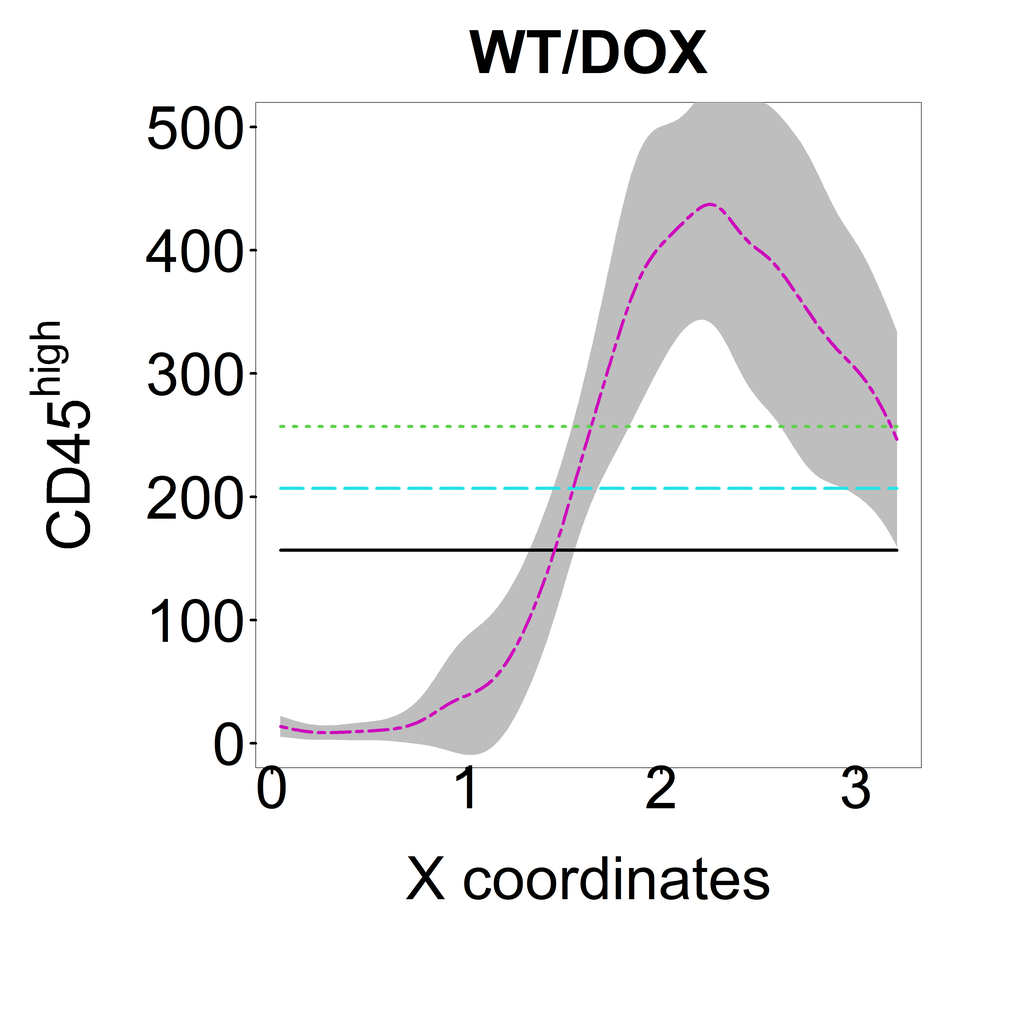

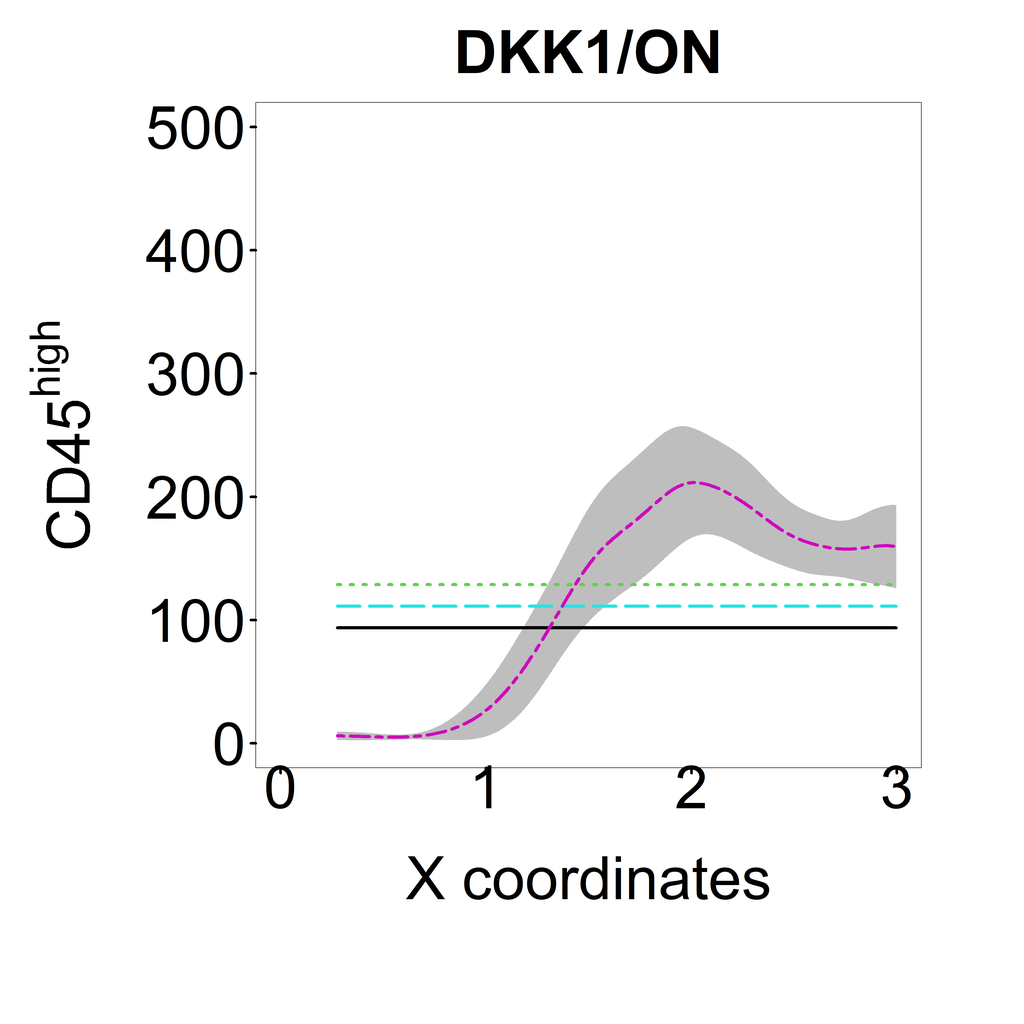

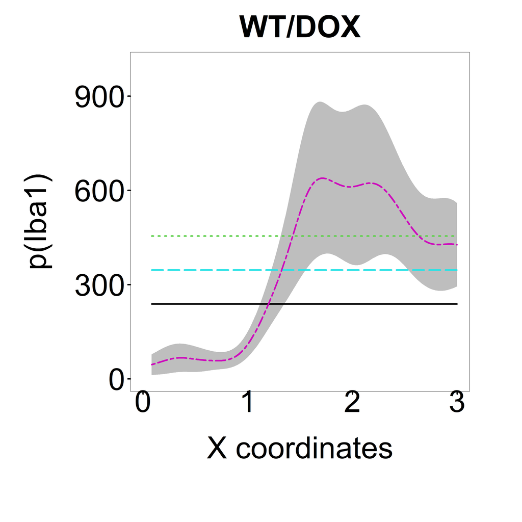

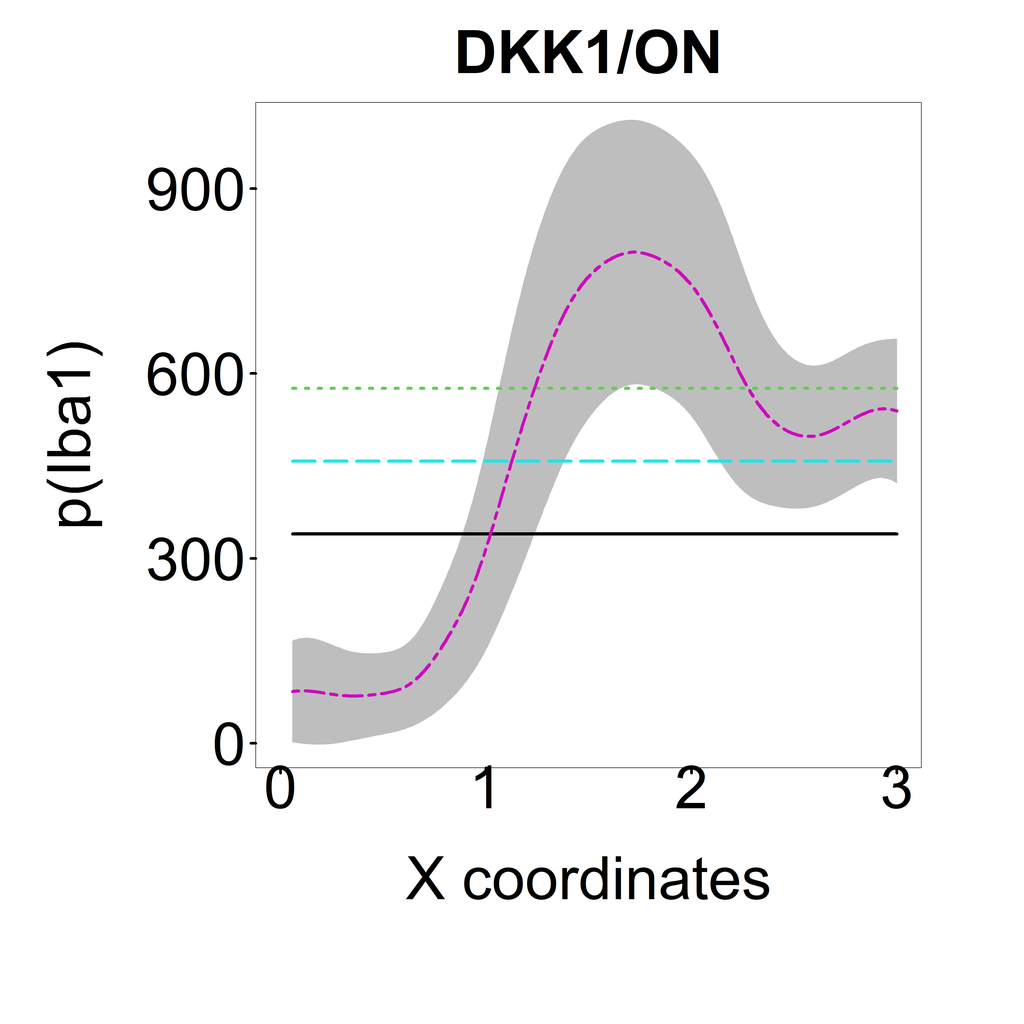

```r
# For CD45 High

par(mar=c(25,25,10,10))
plot(CD45High_Rhohat_WT,
     shade = c("lorho", "hirho"),
     las=1,
     legendargs=list(xpd=TRUE),
     main = "WT/DOX",
     ylim =c(0, 500),
     xlab = "",
     ylab = "",
     cex.main = 7,
     cex.lab = 7,
     cex.axis = 7,
     lwd = 6,
     legend=FALSE,
     xaxt = "n",
     yaxt = "n")

axis(1, at = seq(0, 3, 1), labels = c("0", "1", "2", "3"), cex.axis=7, padj = 0.5, lwd.ticks = 5)

axis(2, at = seq(0, 500, 100), labels = c("0","100", "200", "300", "400", "500"), cex.axis=7, padj = 0.5, lwd.ticks = 5, las = 2)

title(xlab = "X coordinates", mgp = c(12, 1, 0), cex.lab = 7)
title(ylab = expression("CD45"^high), mgp = c(16, 1, 0), cex.lab = 7)
par(mar=c(25,25,10,10))
plot(CD45High_Rhohat_DKK1,
     shade = c("lorho", "hirho"),
     las=1,
     legendargs=list(xpd=TRUE),
     main = "DKK1/ON",
     ylim =c(0, 500),
     xlim =c(0, 3),
     xlab = "",
     ylab = "",
     cex.main = 7,
     cex.lab = 7,
     cex.axis = 7,
     lwd = 6,
     legend=FALSE,
     xaxt = "n",
     yaxt = "n")

axis(1, at = seq(0, 3, 1), labels = c("0", "1", "2", "3"), cex.axis=7, padj = 0.5, lwd.ticks = 5)

axis(2, at = seq(0, 500, 100), labels = c("0","100", "200", "300", "400", "500"), cex.axis=7, padj = 0.5, lwd.ticks = 5, las = 2)

title(xlab = "X coordinates", mgp = c(12, 1, 0), cex.lab = 7)
title(ylab = expression("CD45"^high), mgp = c(16, 1, 0), cex.lab = 7)
par(mar=c(25,25,10,10))
plot(Iba1_Rhohat_WT,
     shade = c("lorho", "hirho"),
     las=1,
     legendargs=list(xpd=TRUE),
     main = "WT/DOX",
     ylim =c(0, 1000),
     xlim =c(0, 3),
     xlab = "",
     ylab = "",
     cex.main = 7,
     cex.lab = 7,
     cex.axis = 7,
     lwd = 6,
     legend=FALSE,
     xaxt = "n",
     yaxt = "n")

axis(1, at = seq(0, 3, 1), labels = c("0", "1", "2", "3"), cex.axis=7, padj = 0.5, lwd.ticks = 5)

axis(2, at = seq(0, 1000, 300), labels = c("0","300", "600", "900"), cex.axis=7, padj = 0.5, lwd.ticks = 5, las = 2)

title(xlab = "X coordinates", mgp = c(12, 1, 0), cex.lab = 7)
title(ylab = "p(Iba1)", mgp = c(16, 1, 0), cex.lab = 7)
par(mar=c(25,25,10,10))
plot(Iba1_Rhohat_DKK1,
     shade = c("lorho", "hirho"),
     las=1,
     legendargs=list(xpd=TRUE),
     main = "DKK1/ON",
     ylim =c(0, 1000),
     xlim =c(0, 3),
     xlab = "",
     ylab = "",
     cex.main = 7,
     cex.lab = 7,
     cex.axis = 7,
     lwd = 6,
     legend=FALSE,
     xaxt = "n",
     yaxt = "n")

axis(1, at = seq(0, 3, 1), labels = c("0", "1", "2", "3"), cex.axis=7, padj = 0.5, lwd.ticks = 5)

axis(2, at = seq(0, 1000, 300), labels = c("0","300", "600", "900"), cex.axis=7, padj = 0.5, lwd.ticks = 5, las = 2)

title(xlab = "X coordinates", mgp = c(12, 1, 0), cex.lab = 7)
title(ylab = "p(Iba1)", mgp = c(16, 1, 0), cex.lab = 7)
```

# 3. Fit a point process model

We fit a spatial model for replicated point patterns using the `mppm` function from `spatstat` to estimate differences between the spatial intensity in WT and DKK1 mice. The model takes the notation:

$λ(u) = \exp(µ + α_{Condition(u)})$

Were the parameters α are the influence of each condition (WT or DKK).

```r
# Fit model for CD45
CD45_fit1 <- mppm(CD45High ~ Condition, PPP_Iba1_CD45)

# We extract the confidence intervals
CD45_fit1_CI <- confint(CD45_fit1)

# Plot coefficients and confidence intervals
CD45_fit1
```

```
Point process model fitted to 17 point patterns
Call: mppm(CD45High ~ Condition, PPP_Iba1_CD45)
Log trend formula: ~Condition

Fitted trend coefficients:
(Intercept) ConditionWT
  4.7094468   0.6173211

Interaction for all patterns:   Poisson process
```

```r
CD45_fit1_CI
```

```
                2.5 %   97.5 %
(Intercept) 4.6944110 4.724483
ConditionWT 0.5972493 0.637393
```

```r
# Fit model for Iba1
Iba1_fit1 <- mppm(Iba1 ~ Condition, PPP_Iba1_CD45)

# We extract the confidence intervals
Iba1_fit1_CI <- confint(Iba1_fit1)

# Plot coefficients and confidence intervals
Iba1_fit1
```

```
Point process model fitted to 17 point patterns
Call: mppm(Iba1 ~ Condition, PPP_Iba1_CD45)
Log trend formula: ~Condition

Fitted trend coefficients:
(Intercept) ConditionWT
  6.1359521  -0.2752704

Interaction for all patterns:   Poisson process
```

```r
Iba1_fit1_CI
```

```
                 2.5 %     97.5 %
(Intercept)  6.1286394  6.1432647
ConditionWT -0.2874591 -0.2630818
```

# 4. Plot density maps for Iba1 and CD45

In this section, we use the `superimpose` function to merge (superimpose) all the point patterns per group. Then, the `unmark` function is employed to allow the calculation of a density kernel (the `density` function is not available for marked point patterns. Next, we calculate the density kernel per group, using the `density` function and plot the images.

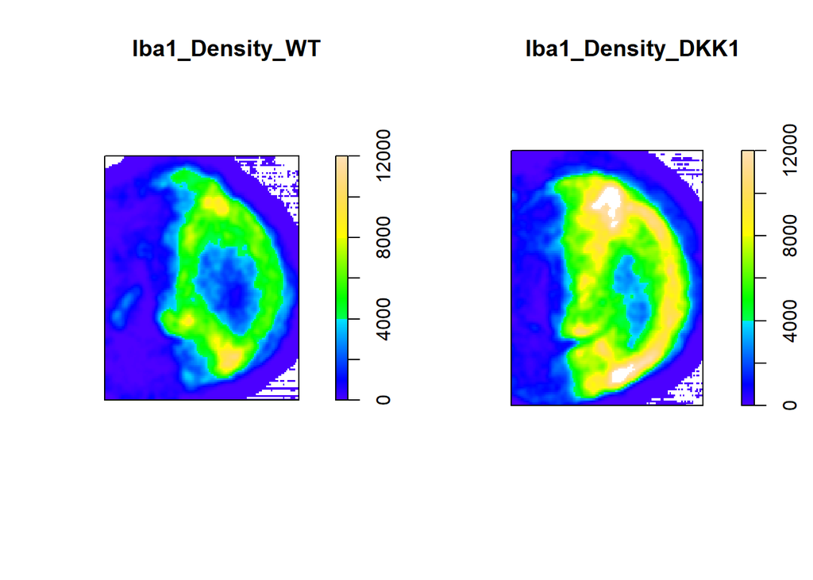

```r
# Superimpose brains for Iba1
Iba1_Superimposed_WT <- superimpose(PPP_Iba1_CD45_WT$Iba1)
Iba1_Superimposed_WT <- unmark(Iba1_Superimposed_WT)

Iba1_Superimposed_DKK1 <- superimpose(PPP_Iba1_CD45_Dkk1$Iba1)
Iba1_Superimposed_DKK1 <- unmark(Iba1_Superimposed_DKK1)

# Plot superimposed brains
Iba1_Density_WT <- density(Iba1_Superimposed_WT, sigma = 0.05)
Iba1_Density_DKK1 <- density(Iba1_Superimposed_DKK1, sigma = 0.05)

Iba1_Super_Colmap <- colourmap(topo.colors(250), range = c(0, 12000))
par(mfrow=c(1,2))
plot(Iba1_Density_WT, col=Iba1_Super_Colmap)
plot(Iba1_Density_DKK1, col= Iba1_Super_Colmap)
```

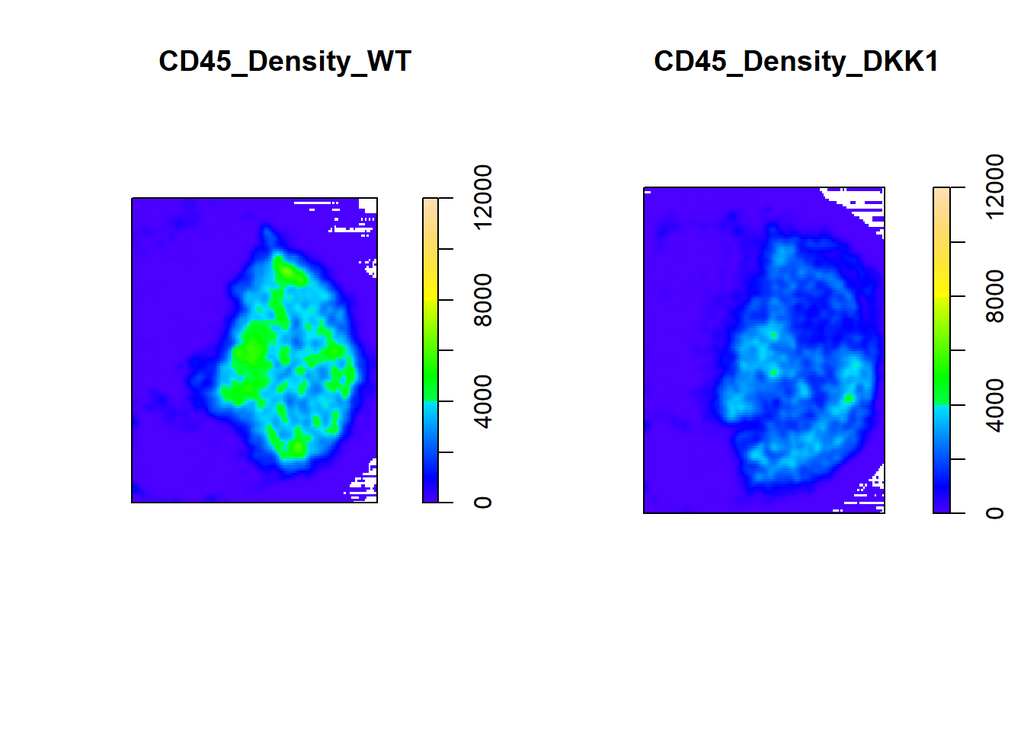

```r
# Superimpose brains for CD45
CD45_Superimposed_WT <- superimpose(PPP_Iba1_CD45_WT$CD45High)
CD45_Superimposed_WT <- unmark(CD45_Superimposed_WT)

CD45_Superimposed_DKK1 <- superimpose(PPP_Iba1_CD45_Dkk1$CD45High)
CD45_Superimposed_DKK1 <- unmark(CD45_Superimposed_DKK1)

# Plot superimposed brains
CD45_Density_WT <- density(CD45_Superimposed_WT, sigma = 0.05)
CD45_Density_DKK1 <- density(CD45_Superimposed_DKK1, sigma = 0.05)

par(mfrow=c(1,2))
plot(CD45_Density_WT, col=Iba1_Super_Colmap)
plot(CD45_Density_DKK1, col= Iba1_Super_Colmap)
```

# 5. Additional data analysis

## 5.1 Analysis of neurological score

We fit an ordinal logistic regression model using the “polr” function from the MASS package (*3*) to analyze the neurological score at 24 hours and 3 days following injury. We use ‘score’ as the outcome variable, and ‘Time’ and ‘Group’ as predictor variables.

```r
# We load the data set
NeurologicalScore <- read.csv(file = 'NSS Dkk1-stroke.csv', header = TRUE)

# We specify the factor levels for Gropus
NeurologicalScore$Group <- factor(NeurologicalScore$Group, levels = c("DKK1/OFF", "WT/DOX", "DKK1/ON"))

# We convert the score to factor (ordered)
NeurologicalScore$Score <- as.factor(NeurologicalScore$Score)

# Fit the model
NeurologicalScore_Mdl1 <- polr(as.ordered(Score) ~ Time * Group, data = NeurologicalScore, Hess = TRUE)

# Print a summary of the model
summary(NeurologicalScore_Mdl1)
```

```
Call:
polr(formula = as.ordered(Score) ~ Time * Group, data = NeurologicalScore,
    Hess = TRUE)

Coefficients:
                    Value Std. Error t value
Time              -0.5307     0.5999 -0.8848
GroupWT/DOX        0.9015     1.6117  0.5593
GroupDKK1/ON       2.7599     1.8527  1.4896
Time:GroupWT/DOX  -0.6677     0.7524 -0.8875
Time:GroupDKK1/ON  0.5990     0.8142  0.7357

Intercepts:
      Value   Std. Error t value
0|0.5 -5.1593  1.6966    -3.0410
0.5|1 -3.2905  1.4191    -2.3188
1|1.5 -1.0551  1.2773    -0.8261
1.5|2 -0.4967  1.2591    -0.3944
2|2.5  1.3754  1.3208     1.0414
2.5|3  2.6779  1.4220     1.8833
3|3.5  5.3458  1.7428     3.0674

Residual Deviance: 113.562
AIC: 137.562
```

### 5.1.1 Plot the neurological score (line plot)

Next, we use the `predict` function to generate predictions in the probability scale for each score based on the fitted model.

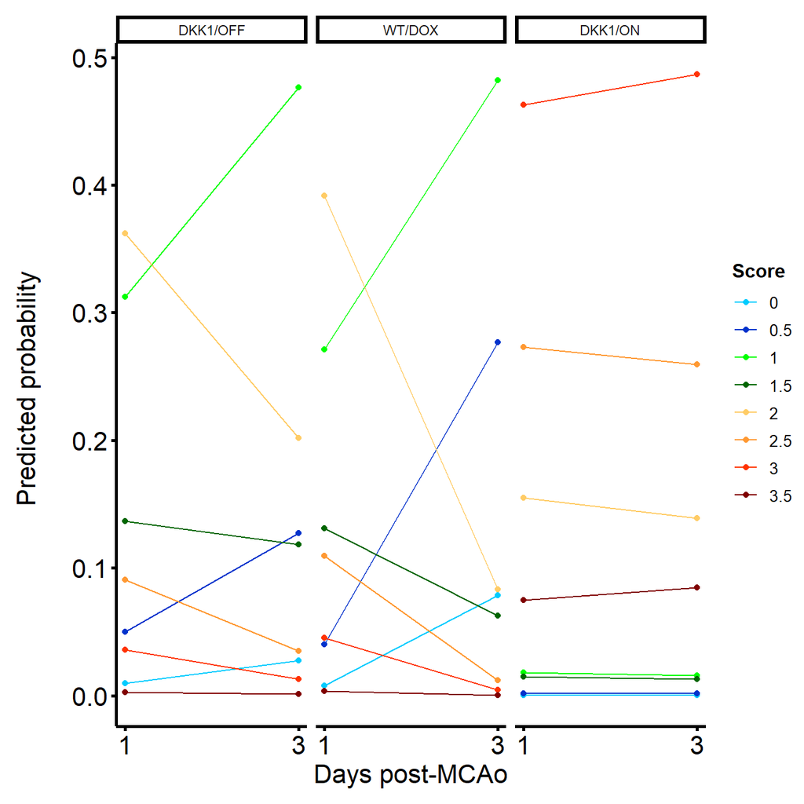

```r
# Create a new data frame for predictions
newdata <- expand.grid(Time = unique(NeurologicalScore$Time),
                       Group = levels(NeurologicalScore$Group))


# Generate predictions
predictions <- predict(NeurologicalScore_Mdl1, newdata = newdata, type = "probs")

# Rename columns of predictions to ensure they're unique
colnames(predictions) <- paste0("Score_", colnames(predictions))

# Add the predictions to the new data frame
newdata <- cbind(newdata, predictions)

# Convert to long format for plotting
predictions_long <- tidyr::pivot_longer(newdata, cols = starts_with("Score_"),
                                        names_to = "Score", values_to = "Probability")

# Remove the "Score_" prefix from the Score variable
predictions_long$Score <- gsub("Score_", "", predictions_long$Score)

# Plot
NeurologicalScore_Fig <- ggplot(predictions_long, aes(x = Time, y = Probability, color = Score)) +
  geom_line() +
  geom_point() +
  labs(x = "Days post-MCAo", y = "Predicted probability \n", color = "Score") +
  scale_x_continuous(
  breaks =c(1, 3)) +

  scale_color_manual(values = c("#00ccff", "#0033cc", "#00ff00", "#006600", "#ffcc66",  "#ff9933", "#ff3300", "#800000")) +

  facet_wrap(~ Group) +
  theme_classic() +


    theme(
      plot.title = element_text(size=18, hjust = 0.5, face="bold"),
      plot.subtitle = element_text(size = 12, color = "black"),
      plot.caption = element_text(size = 12, color = "black"),
      axis.line = element_line(colour = "black", size = 1, linetype = "solid"),
      axis.ticks.length=unit(3,"pt"),

      axis.title.x = element_text(colour = "black", size = 16),
      axis.text.x = element_text(colour = "black", size = 16, angle = 0, hjust = 0.5),
      axis.ticks.x = element_line(colour = "black", size = 1),

      axis.title.y = element_text(colour = "black", size = 16),
      axis.text.y = element_text(colour = "black", size = 16),
      axis.ticks.y = element_line(colour = "black", size = 1),

      legend.position="right",
      legend.direction="vertical",
      legend.title = element_text(colour="black", face="bold", size=12),
      legend.text = element_text(colour="black", size=10),

      strip.background = element_rect(color="black",
                                      size=2,
                                      linetype="solid"),


      plot.margin = margin(t = 10,  # Top margin
                             r = 2,  # Right margin
                             b = 10,  # Bottom margin
                             l = 10) # Left margin
      )

ggsave(
  plot     = NeurologicalScore_Fig,
  filename = "Plots/NeurologicalScore_Fig.png",
  width    = 15,
  height   = 13,
  units    = "cm")

NeurologicalScore_Fig
```

### 5.1.2 Plot the neurological score (Stacked bar)

We used the same data set to created a stacked bar plot accounting for the probability scale.

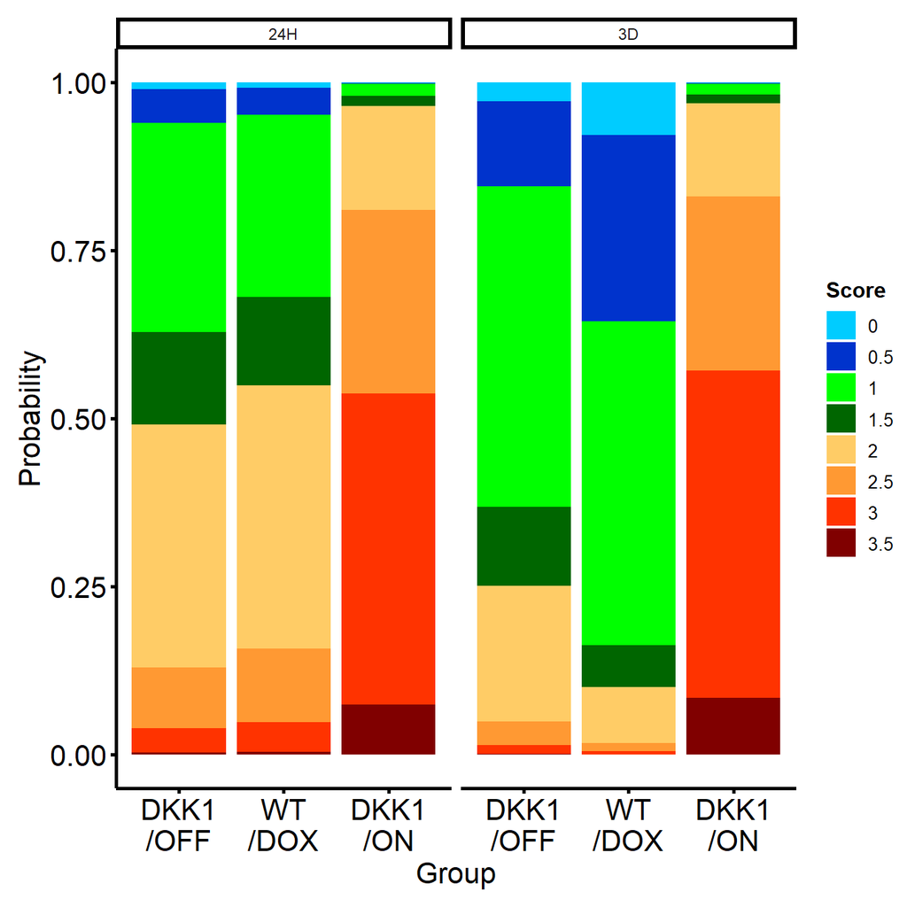

```r
predictions_long$Time2 <- as.factor(predictions_long$Time)

predictions_long$Time2 <- revalue(predictions_long$Time2, c("1" = "24H", "3" = "3D"))

NeurologicalScore_Bar <- ggplot(predictions_long, aes(fill=Score, y=Probability, x=Group)) +

    geom_bar(position="fill", stat="identity") +

  scale_fill_manual(values = c("#00ccff", "#0033cc", "#00ff00", "#006600", "#ffcc66",  "#ff9933", "#ff3300", "#800000")) +

  scale_x_discrete (labels = c("DKK1\n/OFF", "WT\n/DOX", "DKK1\n/ON")) +

   theme_classic() +

    theme(
      plot.title = element_text(size=18, hjust = 0.5, face="bold"),
      plot.subtitle = element_text(size = 12, color = "black"),
      plot.caption = element_text(size = 12, color = "black"),
      axis.line = element_line(colour = "black", size = 1, linetype = "solid"),
      axis.ticks.length=unit(3,"pt"),

      axis.title.x = element_text(colour = "black", size = 16),
      axis.text.x = element_text(colour = "black", size = 16, angle = 0, hjust = 0.5),
      axis.ticks.x = element_line(colour = "black", size = 1),

      axis.title.y = element_text(colour = "black", size = 16),
      axis.text.y = element_text(colour = "black", size = 16),
      axis.ticks.y = element_line(colour = "black", size = 1),

      legend.position="right",
      legend.direction="vertical",
      legend.title = element_text(colour="black", face="bold", size=12),
      legend.text = element_text(colour="black", size=10),

       strip.background = element_rect(color="black",
                                      size=2,
                                      linetype="solid"),

      plot.margin = margin(t = 10,  # Top margin
                             r = 2,  # Right margin
                             b = 10,  # Bottom margin
                             l = 10) # Left margin

    ) +

  facet_grid(~ Time2)

ggsave(
  plot     = NeurologicalScore_Bar,
  filename = "Plots/NeurologicalScore_Bar.png",
  width    = 15,
  height   = 13,
  units    = "cm")


NeurologicalScore_Bar
```

## 5.2 Analysis of horizontal bar test

We fit an ordinal logistic regression model to analize using the horizontal bar test at 24 hours and 3 days following injury. Please note that the scores (time on the rod) are represented as ratios to the baseline value. We preformed a quartile division of the score (“0-0.25”, “0.25-0.50”, “0.50-0.75”, “0.75-1”) as the outcome variable, and ‘Time’ and ‘Group’ as predictor variables.

```r
# We load the data set
HorizontalBar <- read.csv(file = 'DataTables/HorizontalBar_V2.csv', header = TRUE)

# We specify the factor levels for Groups
HorizontalBar$Group <- factor(HorizontalBar$Group, levels = c("DKK1/OFF", "WT/DOX", "DKK1/ON"))

# Define the range boundaries
range <- c(0, 0.25, 0.50, 0.75, 1)
ordinal_labels <- c("0-0.25", "0.25-0.50", "0.50-0.75", "0.75-1")

convert_to_ordinal <- function(Score) {
  category <- cut(Score, range, labels = ordinal_labels, include.lowest = TRUE)
  return(as.character(category))
}

# Apply the conversion function to the Time column in the data set
HorizontalBar$Range <- convert_to_ordinal(HorizontalBar$Score)

# We convert the score to factor (ordered)
HorizontalBar$Range <- factor(HorizontalBar$Range, levels = c("0-0.25", "0.25-0.50", "0.50-0.75", "0.75-1"))

# Fit the model
HorizontalBar_Mdl1 <- polr(as.ordered(Range) ~ Time * Group, data = HorizontalBar, Hess = TRUE)

# Print a summary of the model
summary(HorizontalBar_Mdl1)
```

```
Call:
polr(formula = as.ordered(Range) ~ Time * Group, data = HorizontalBar,
    Hess = TRUE)

Coefficients:
                     Value Std. Error  t value
Time               16.6337     0.4842  34.3498
GroupWT/DOX        -0.4637     1.1967  -0.3875
GroupDKK1/ON       -1.0007     1.1168  -0.8961
Time:GroupWT/DOX  -16.1643     0.7904 -20.4509
Time:GroupDKK1/ON -16.3812     0.7389 -22.1695

Intercepts:
                    Value    Std. Error t value
0-0.25|0.25-0.50     -1.7552   0.9493    -1.8489
0.25-0.50|0.50-0.75  -0.9506   0.9058    -1.0495
0.50-0.75|0.75-1     -0.2749   0.8975    -0.3063

Residual Deviance: 78.08642
AIC: 94.08642
(7 observations deleted due to missingness)
```

### 5.1.1 Plot the horizontal bar score (line plot)

Next, we use the `predict` function to generate predictions in the probability scale for each score based on the fitted model.

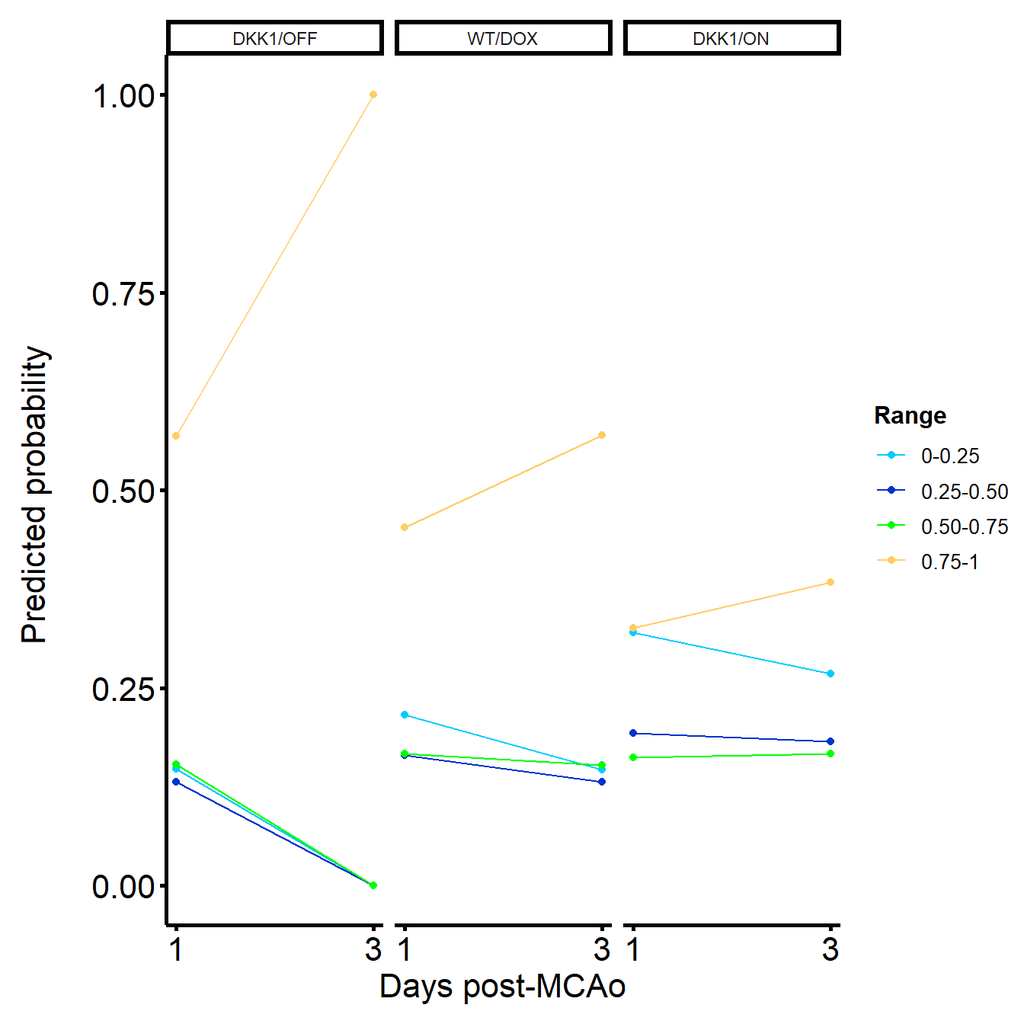

```r
# Create a new data frame for predictions
newdata <- expand.grid(Time = unique(HorizontalBar$Time),
                       Group = levels(HorizontalBar$Group))


# Generate predictions
predictions <- predict(HorizontalBar_Mdl1, newdata = newdata, type = "probs")

# Rename columns of predictions to ensure they're unique
colnames(predictions) <- paste0("Range_", colnames(predictions))

# Add the predictions to the new data frame
newdata <- cbind(newdata, predictions)

# Convert to long format for plotting
predictions_long <- tidyr::pivot_longer(newdata, cols = starts_with("Range_"),
                                        names_to = "Range", values_to = "Probability")

# Remove the "Score_" prefix from the Score variable
predictions_long$Score <- gsub("Range_", "", predictions_long$Range)

# Plot
HorizontalBar_Fig <- ggplot(predictions_long, aes(x = Time, y = Probability, color = Score)) +
  geom_line() +
  geom_point() +
  labs(x = "Days post-MCAo", y = "Predicted probability \n", color = "Range") +
  scale_x_continuous(
  breaks =c(0, 1),
  labels = c ("1", "3")) +

  scale_color_manual(values = c("#00ccff", "#0033cc", "#00ff00", "#ffcc66",  "#ff3300", "#800000")) +

  facet_wrap(~ Group) +
  theme_classic() +


    theme(
      plot.title = element_text(size=18, hjust = 0.5, face="bold"),
      plot.subtitle = element_text(size = 12, color = "black"),
      plot.caption = element_text(size = 12, color = "black"),
      axis.line = element_line(colour = "black", size = 1, linetype = "solid"),
      axis.ticks.length=unit(3,"pt"),

      axis.title.x = element_text(colour = "black", size = 16),
      axis.text.x = element_text(colour = "black", size = 16, angle = 0, hjust = 0.5),
      axis.ticks.x = element_line(colour = "black", size = 1),

      axis.title.y = element_text(colour = "black", size = 16),
      axis.text.y = element_text(colour = "black", size = 16),
      axis.ticks.y = element_line(colour = "black", size = 1),

      legend.position="right",
      legend.direction="vertical",
      legend.title = element_text(colour="black", face="bold", size=12),
      legend.text = element_text(colour="black", size=10),

      strip.background = element_rect(color="black",
                                      size=2,
                                      linetype="solid"),


      plot.margin = margin(t = 10,  # Top margin
                             r = 2,  # Right margin
                             b = 10,  # Bottom margin
                             l = 10) # Left margin
      )

ggsave(
  plot     = HorizontalBar_Fig,
  filename = "Plots/HorizontalBar_Fig.png",
  width    = 15,
  height   = 13,
  units    = "cm")

HorizontalBar_Fig
```

## 5.3. DKK1 and IgG correlation

We perform a correlation between DKK1 expression and IgG. First, we load the data set

```r
DKK1_IgG <- read.csv(file = 'DataTables/DKK1_IgG.csv', header = TRUE)
```

### 5.3.1 Initial data visualization

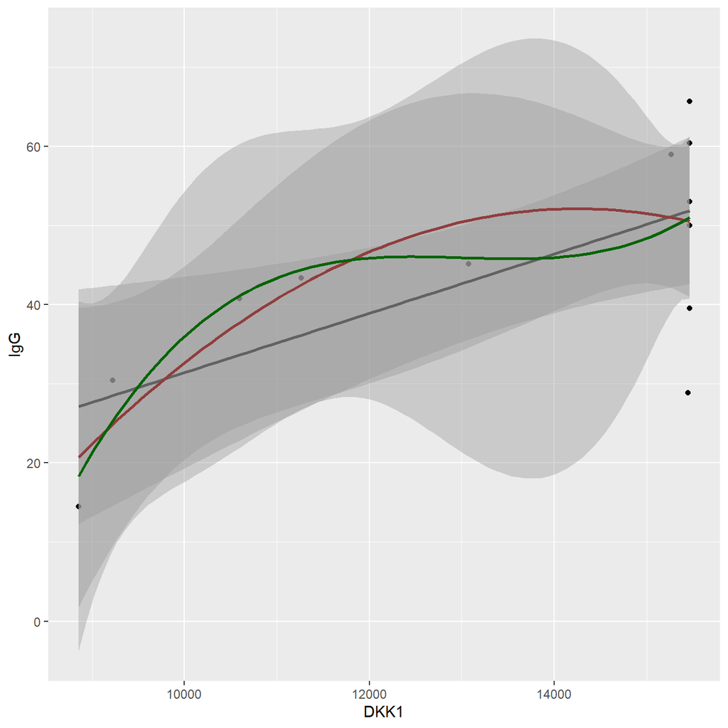

```r
ggplot(DKK1_IgG, aes(x = DKK1, y = IgG)) +
  geom_point() +
  geom_smooth(
  method = "lm",
  se     = TRUE,
  color  = "black") +
geom_smooth(
  method  = "lm",
  se      = TRUE,
  formula = y ~ poly(x, 2),
  color   = "darkred") +
  geom_smooth(
  method  = "lm",
  se      = TRUE,
  formula = y ~ poly(x, 3),
  color   = "darkgreen")
```

First, we exclude the DKK1 values reaching the threshold above 14000.

```r
filtered_data <- DKK1_IgG %>%
  filter(DKK1 <= 14000)
```

We plot again the function

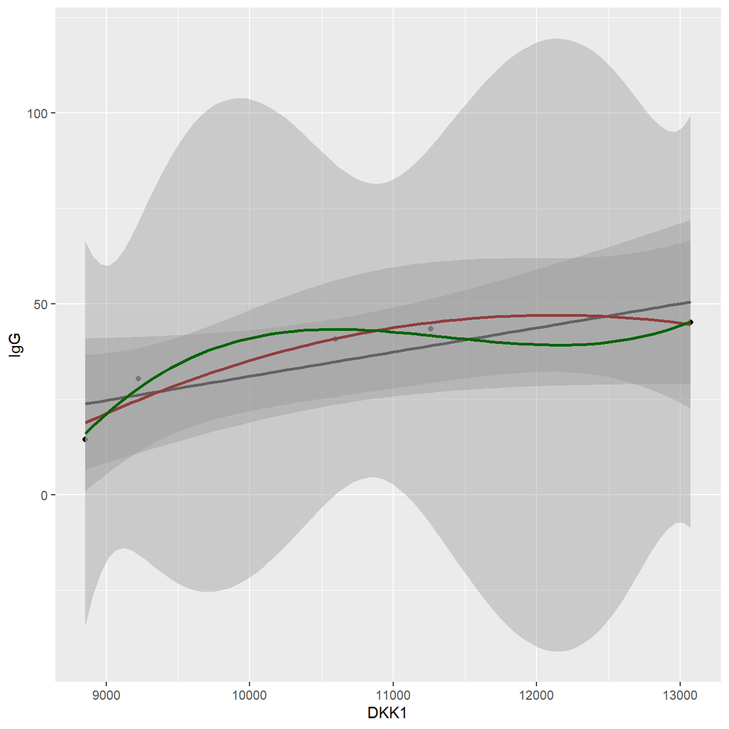

```r
ggplot(filtered_data, aes(x = DKK1, y = IgG)) +
  geom_point() +
  geom_smooth(
  method = "lm",
  se     = TRUE,
  color  = "black") +
geom_smooth(
  method  = "lm",
  se      = TRUE,
  formula = y ~ poly(x, 2),
  color   = "darkred") +
  geom_smooth(
  method  = "lm",
  se      = TRUE,
  formula = y ~ poly(x, 3),
  color   = "darkgreen")
```

Now, we see that the similarity with linearity is stronger. Therefore, we are going to postulate a liner model to fit the data.

```r
DKK1_IgG_Model <- lm(DKK1 ~ IgG, data = filtered_data)

summary(DKK1_IgG_Model)
```

```
Call:
lm(formula = DKK1 ~ IgG, data = filtered_data)

Residuals:
     1      2      3      4      5
-667.2 -299.6 -881.3  536.7 1311.4

Coefficients:
            Estimate Std. Error t value Pr(>|t|)
(Intercept)  6694.26    1514.10   4.421   0.0215 *
IgG           112.18      41.31   2.716   0.0728 .
---
Signif. codes:  0 '***' 0.001 '**' 0.01 '*' 0.05 '.' 0.1 ' ' 1

Residual standard error: 1052 on 3 degrees of freedom
Multiple R-squared:  0.7109,    Adjusted R-squared:  0.6145
F-statistic: 7.375 on 1 and 3 DF,  p-value: 0.07281
```

```r
coefficients <- summary(DKK1_IgG_Model)$coefficients
r_squared <- summary(DKK1_IgG_Model)$r.squared
```

### 5.3.2 Plot results with predictions:

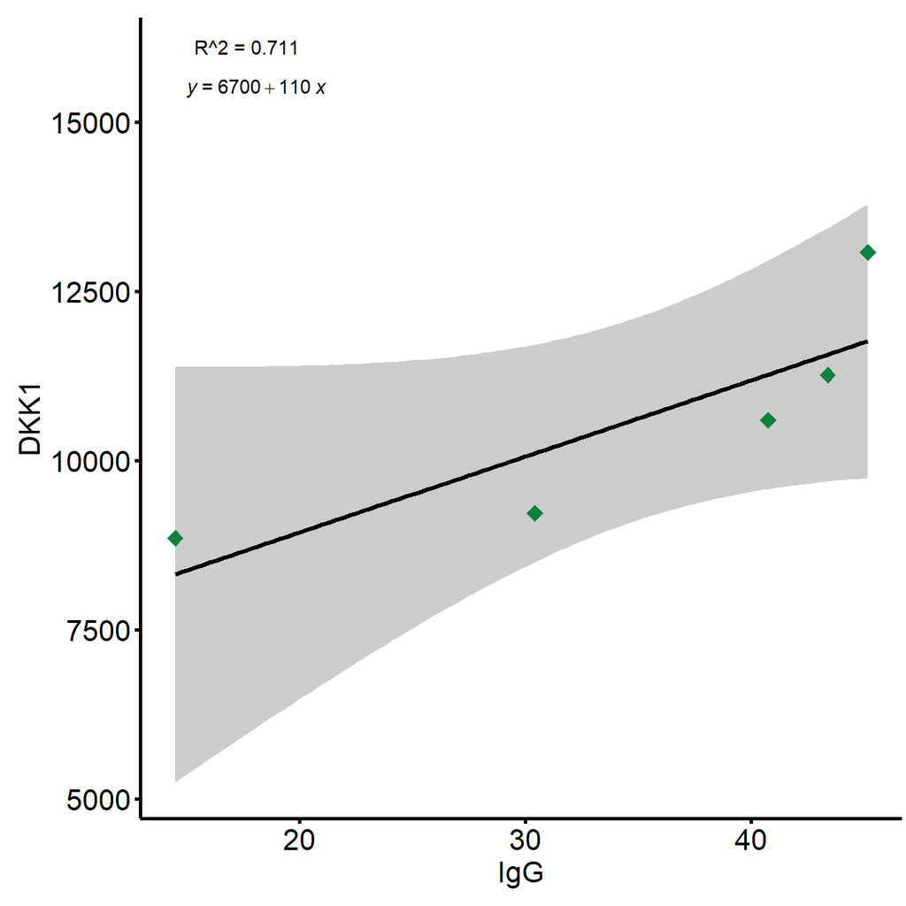

```r
DKK1_IgG_Plot <- effect_plot(DKK1_IgG_Model, pred = IgG, interval = TRUE, plot.points = FALSE, data = filtered_data) +
  stat_regline_equation(label.x = 15, label.y = 15500) +
  geom_point(data = filtered_data, aes(x = IgG, y=DKK1), color = "#107F40", fill = "#107F40", size = 3, shape = 23) +


annotate("text", x = 20, y = 16000, label = paste0("R^2 = ", round(r_squared, 3)), hjust = 1, vjust = 0) +

  theme_classic() +
  theme(
      plot.title = element_text(size=18, hjust = 0.5, face="bold"),
      plot.subtitle = element_text(size = 12, color = "black"),
      plot.caption = element_text(size = 12, color = "black"),
      axis.line = element_line(colour = "black", size = 1, linetype = "solid"),
      axis.ticks.length=unit(3,"pt"),

      axis.title.x = element_text(colour = "black", size = 16),
      axis.text.x = element_text(colour = "black", size = 16, angle = 0, hjust = 0.5),
      axis.ticks.x = element_line(colour = "black", size = 1),

      axis.title.y = element_text(colour = "black", size = 16),
      axis.text.y = element_text(colour = "black", size = 16),
      axis.ticks.y = element_line(colour = "black", size = 1),

      legend.position="right",
      legend.direction="vertical",
      legend.title = element_text(colour="black", face="bold", size=12),
      legend.text = element_text(colour="black", size=10),

      plot.margin = margin(t = 10,  # Top margin
                             r = 2,  # Right margin
                             b = 10,  # Bottom margin
                             l = 10) # Left margin
      )

ggsave(
  plot     = DKK1_IgG_Plot ,
  filename = "Plots/DKK1_IgG_Plot .png",
  width    = 13.5,
  height   = 11.25,
  units    = "cm")

DKK1_IgG_Plot
```

# References

1.

P. Bankhead, M. B. Loughrey, J. A. Fernández, Y. Dombrowski, D. G. McArt, P. D. Dunne, S. McQuaid, R. T. Gray, L. J. Murray, H. G. Coleman, J. A. James, M. Salto-Tellez, P. W. Hamilton, QuPath: Open source software for digital pathology image analysis. *Scientific Reports*. **7** (2017), doi:10.1038/s41598-017-17204-5.

2.

A. Baddeley, E. Rubak, R. Turner, Spatial point patterns: Methodology and applications with r (2015) (available at https://www.routledge.com/Spatial-Point-Patterns-Methodology-and-Applications-with-R/Baddeley-Rubak-Turner/p/book/9781482210200/).

3.

W. N. Venables, B. D. Ripley, Modern applied statistics with s (2002) (available at https://www.stats.ox.ac.uk/pub/MASS4/).